# Eval_Lab

Brian Wright

10/25/2020

## Metrics Evaluation Lab

Throughout your early career as a Data Scientist you’ve built article summaries, explored NBA talent, and analyzed text on climate change news but you’ve suddenly realized you need to enhance your ability to assess the models you are building. As the most important part about understanding any machine learning model (or any model, really) is understanding it’s weakness and/or vulnerabilities.

In doing so you’ve decided to practice on datasets that are of interest to you, and use a approach to which you are (becoming) familiar, kNN.

### Part 1: Defining a Question

We will be using a Breast Cancer dataset ufrom Wisconcsin taken from [Kaggle](https://www.kaggle.com/uciml/breast-cancer-wisconsin-data). **Question**: Given the characteristics of a tumor, can we predict whether the patient’s tumor is malignant or not?

####Load Essential Libraries

####Loading the Dataset

```r
b_cancer <- read_csv("breast_cancer.csv")
```

```
## * `` -> ...33
```

```r
table(is.na(b_cancer)) #checks if there are NAs present
```

```
##
## FALSE  TRUE
## 18176   568
```

```r
#all of the NAs are present in one column so take that column out
b_cancer <- b_cancer[ ,2:32]
b_cancer <- b_cancer[complete.cases(b_cancer), ]
table(is.na(b_cancer))
```

```
##
## FALSE
## 17608
```

```r
# there are 31 predictor variables
b_cancer$diagnosis <- recode(b_cancer$diagnosis, 'B'=0, 'M'=1)
str(b_cancer)
```

```
## tibble [568 x 31] (S3: tbl_df/tbl/data.frame)
##  $ diagnosis              : num [1:568] 1 1 1 1 1 1 1 1 1 1 ...
##  $ radius_mean            : num [1:568] 18 20.6 19.7 11.4 20.3 ...
##  $ texture_mean           : num [1:568] 10.4 17.8 21.2 20.4 14.3 ...
##  $ perimeter_mean         : num [1:568] 122.8 132.9 130 77.6 135.1 ...
##  $ area_mean              : num [1:568] 1001 1326 1203 386 1297 ...
##  $ smoothness_mean        : num [1:568] 0.1184 0.0847 0.1096 0.1425 0.1003 ...
##  $ compactness_mean       : num [1:568] 0.2776 0.0786 0.1599 0.2839 0.1328 ...
##  $ concavity_mean         : num [1:568] 0.3001 0.0869 0.1974 0.2414 0.198 ...
##  $ concave points_mean    : num [1:568] 0.1471 0.0702 0.1279 0.1052 0.1043 ...
##  $ symmetry_mean          : num [1:568] 0.242 0.181 0.207 0.26 0.181 ...
##  $ fractal_dimension_mean : num [1:568] 0.0787 0.0567 0.06 0.0974 0.0588 ...
##  $ radius_se              : num [1:568] 1.095 0.543 0.746 0.496 0.757 ...
##  $ texture_se             : num [1:568] 0.905 0.734 0.787 1.156 0.781 ...
##  $ perimeter_se           : num [1:568] 8.59 3.4 4.58 3.44 5.44 ...
```

[output cut: 17 more lines]

```r
#reduce the amount of predictor variables to 11
b_cancer_rev <- (b_cancer[ ,1:31])
```

### Part 2: Deciding which metrics to use

The three key metrics that should be tracked given our question are the False Negative Rate, Balanced Accuracy, and the F1 score. The False Negative rate is important to calculate because we want the number of people who have a malignant tumor to be diagnosed with a malignant tumor rather than a benign tumor. We are aiming for a low false negative rate so that people will get the treatment that they need for the tumor. Another metric would be to calculate balanced accuracy. Balanced accuracy is better to use with imbalanced data, which is what our data set looks like and is important to validate the accuracy of the entire model. The F1 score is also an important measure because it will predict the model’s ability to reduce the amount of false positives or false negatives as a false negative could indicate that a patient with a malignant tumor is diagnosed to not have a malignant tumor

### Part 3: Building a kNN model

#### Building the kNN model

```r
b_cancer_rev$diagnosis <- as.factor(b_cancer_rev$diagnosis)
b_cancer_pred <- b_cancer_rev
scaled_cancer <- as.data.frame(scale(b_cancer_pred[2:31], center = TRUE, scale = TRUE))
set.seed(1000)
scaled_cancer['diagnosis'] <- b_cancer_pred[ ,1]
cancer_sample <- sample(2, nrow(scaled_cancer), replace=TRUE, prob=c(0.67, 0.33))


cancer_training <- scaled_cancer[cancer_sample==1, 1:30]
cancer_test <- scaled_cancer[cancer_sample==2, 1:30]

cancer.trainLabels <- scaled_cancer[cancer_sample==1, 31]
cancer.testLabels <- scaled_cancer[cancer_sample==2, 31]

cancer_pred <- knn(train=cancer_training, test = cancer_test, cl = cancer.trainLabels, k=5, prob=TRUE)

View(cancer_pred)
View(attr(cancer_pred, "prob"))


CANCERCross <- CrossTable(cancer.testLabels, cancer_pred, prop.chisq=FALSE)
```

```
##
##
##    Cell Contents
## |-------------------------|
## |                       N |
## |           N / Row Total |
## |           N / Col Total |
## |         N / Table Total |
## |-------------------------|
##
##
## Total Observations in Table:  201
##
##
##                   | cancer_pred
## cancer.testLabels |         0 |         1 | Row Total |
## ------------------|-----------|-----------|-----------|
##                 0 |       126 |         1 |       127 |
##                   |     0.992 |     0.008 |     0.632 |
##                   |     0.977 |     0.014 |           |
##                   |     0.627 |     0.005 |           |
## ------------------|-----------|-----------|-----------|
##                 1 |         3 |        71 |        74 |
##                   |     0.041 |     0.959 |     0.368 |
##                   |     0.023 |     0.986 |           |
##                   |     0.015 |     0.353 |           |
## ------------------|-----------|-----------|-----------|
##      Column Total |       129 |        72 |       201 |
##                   |     0.642 |     0.358 |           |
## ------------------|-----------|-----------|-----------|
##
##
```

```r
# the cross table shows the confusion matrix
```

#### Using karet with 10-k Cross-Validation

```r
set.seed(1981)
scaled_cancer$diagnosis <- b_cancer_rev$diagnosis
cancer_training_car <- scaled_cancer[cancer_sample==1, 1:31]
cancer_test_car <- scaled_cancer[cancer_sample==2, 1:31]

trctrl <- trainControl(method = "repeatedcv",
                       number = 10,
                       repeats = 3)
cancer_knn <- train(diagnosis~., data = cancer_training_car,
                    method="knn",
                    tuneLength=10,
                    trControl = trctrl,
                    preProcess="scale")
cancer_knn
```

```
## k-Nearest Neighbors
##
## 367 samples
##  30 predictor
##   2 classes: '0', '1'
##
## Pre-processing: scaled (30)
## Resampling: Cross-Validated (10 fold, repeated 3 times)
## Summary of sample sizes: 330, 331, 330, 330, 330, 332, ...
## Resampling results across tuning parameters:
##
##   k   Accuracy   Kappa
##    5  0.9637387  0.9216952
##    7  0.9573559  0.9077707
##    9  0.9564050  0.9050587
##   11  0.9573309  0.9068101
##   13  0.9528264  0.8965358
##   15  0.9518754  0.8942941
##   17  0.9500736  0.8899021
##   19  0.9500736  0.8899021
##   21  0.9482468  0.8857668
##   23  0.9482718  0.8859617
##
## Accuracy was used to select the optimal model using the largest value.
## The final value used for the model was k = 5.
```

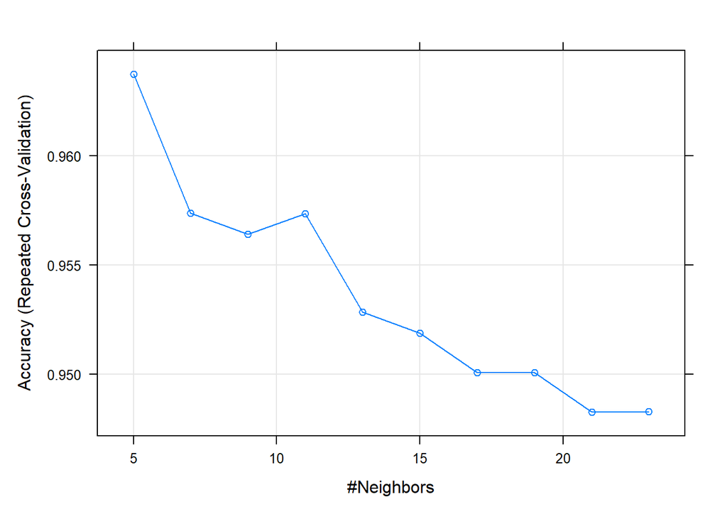

```r
plot(cancer_knn)
```

```r
varImp(cancer_knn)
```

```
## ROC curve variable importance
##
##   only 20 most important variables shown (out of 30)
##
##                      Importance
## perimeter_worst          100.00
## area_worst                99.30
## radius_worst              99.11
## concave points_worst      95.44
## concave points_mean       95.38
## perimeter_mean            94.07
## area_mean                 92.66
## radius_mean               92.40
## area_se                   90.18
## concavity_mean            89.60
## concavity_worst           86.42
## perimeter_se              78.98
## radius_se                 77.49
## compactness_worst         72.88
## compactness_mean          72.73
## concave points_se         58.71
## texture_worst             57.36
## texture_mean              56.28
## concavity_se              56.10
## smoothness_worst          48.57
```

The optimal model used k=5 and we had believed that a higher k would be able to capture a lower false negative rate. The kappa value for k=5 was predicted to be 0.9216952.

####Evaluation Metrics

**ACCURACY**: The overall accuracy of the model was found to be 98% and the Balanced accuracy was also found to be 0.976. The accuracy of the model is a good factor to determine if your model is good or not, but should not be the core of evaluating the model. The balanced accuracy is also important because it takes into account the imbalanced data, and averages sensitivity and specificity.

**KAPPA**: The Kappa value was calculated to be 0.95, which increases my belief that the model is predicting the classes well on an imbalanced dataset.

#### Specific Evaluation Metrics

```r
#First we need to do some predictions using the test data
cancer_eval <-(predict(cancer_knn,newdata = cancer_test_car))#generates 1s and 0s
cancer_eval_prob <- predict(cancer_knn,newdata = cancer_test_car, type = "prob")#this gives us the predicted prob, we will need these later for the fairness evaluation
View(cancer_eval_prob)

View(cancer_test_car$diagnosis)
table(cancer_eval, cancer_test_car$diagnosis)
```

```
##
## cancer_eval   0   1
##           0 126   3
##           1   1  71
```

```r
confusionMatrix(cancer_eval, cancer_test_car$diagnosis, positive="1", dnn=c("Prediction", "Actual"), mode="sens_spec")
```

```
## Confusion Matrix and Statistics
##
##           Actual
## Prediction   0   1
##          0 126   3
##          1   1  71
##
##                Accuracy : 0.9801
##                  95% CI : (0.9498, 0.9946)
##     No Information Rate : 0.6318
##     P-Value [Acc > NIR] : <2e-16
##
##                   Kappa : 0.957
##
##  Mcnemar's Test P-Value : 0.6171
##
##             Sensitivity : 0.9595
##             Specificity : 0.9921
##          Pos Pred Value : 0.9861
##          Neg Pred Value : 0.9767
##              Prevalence : 0.3682
##          Detection Rate : 0.3532
##    Detection Prevalence : 0.3582
##       Balanced Accuracy : 0.9758
##
##        'Positive' Class : 1
##
```

```r
#use the adjust_thresh function to explore various threshold levels
adjust_thres <- function(x, y, z) {
  #x=pred_probablities, y=threshold, z=test_outcome
  thres <- as.factor(ifelse(x > y, 1,0))
  confusionMatrix(thres, z, positive = "1", dnn=c("Prediction", "Actual"), mode = "everything")
}

#0.8 from class example
adjust_thres(cancer_eval_prob$'1', 0.8, cancer_test_car$diagnosis)
```

```
## Confusion Matrix and Statistics
##
##           Actual
## Prediction   0   1
##          0 127  12
##          1   0  62
##
##                Accuracy : 0.9403
##                  95% CI : (0.898, 0.9688)
##     No Information Rate : 0.6318
##     P-Value [Acc > NIR] : < 2.2e-16
##
##                   Kappa : 0.8672
##
##  Mcnemar's Test P-Value : 0.001496
##
##             Sensitivity : 0.8378
##             Specificity : 1.0000
##          Pos Pred Value : 1.0000
##          Neg Pred Value : 0.9137
##               Precision : 1.0000
##                  Recall : 0.8378
##                      F1 : 0.9118
##              Prevalence : 0.3682
##          Detection Rate : 0.3085
##    Detection Prevalence : 0.3085
##       Balanced Accuracy : 0.9189
##
##        'Positive' Class : 1
##
```

```r
# the algorithm predicted that one patient who has no cancer would be diagnosed with cancer // decrease the true positive rate // increased sensitivity
cancer_eval_prob$test <- cancer_test_car$diagnosis

(error = mean(cancer_eval != cancer_test_car$diagnosis))
```

```
## [1] 0.0199005
```

```r
# the overall error rate is 0.0199
```

**Important Metric Values**

Accuracy: 94.03%

Kappa: 0.8672

Balanced Accuracy: 0.9189

Prevalence: 0.3682

The error rate was calculated and the error rate was found to be 0.0199, verifying that the model is valid.

```r
FNR <- 3/(3+71)
FNR
```

```
## [1] 0.04054054
```

```r
pr <- 126/(126+1)
pr
```

```
## [1] 0.992126
```

False Negative Rate: 0.04

#### ROC/AUC Plot

```r
cancer_eval <- data.frame(pred_class=cancer_eval, pred_prob=cancer_eval_prob$'1',target=as.numeric(cancer_test_car$diagnosis))
str(cancer_eval)
```

```
## 'data.frame':    201 obs. of  3 variables:
##  $ pred_class: Factor w/ 2 levels "0","1": 2 2 2 2 2 2 1 2 2 2 ...
##  $ pred_prob : num  1 1 1 1 0.6 1 0 1 1 1 ...
##  $ target    : num  2 2 2 2 2 2 1 2 2 2 ...
```

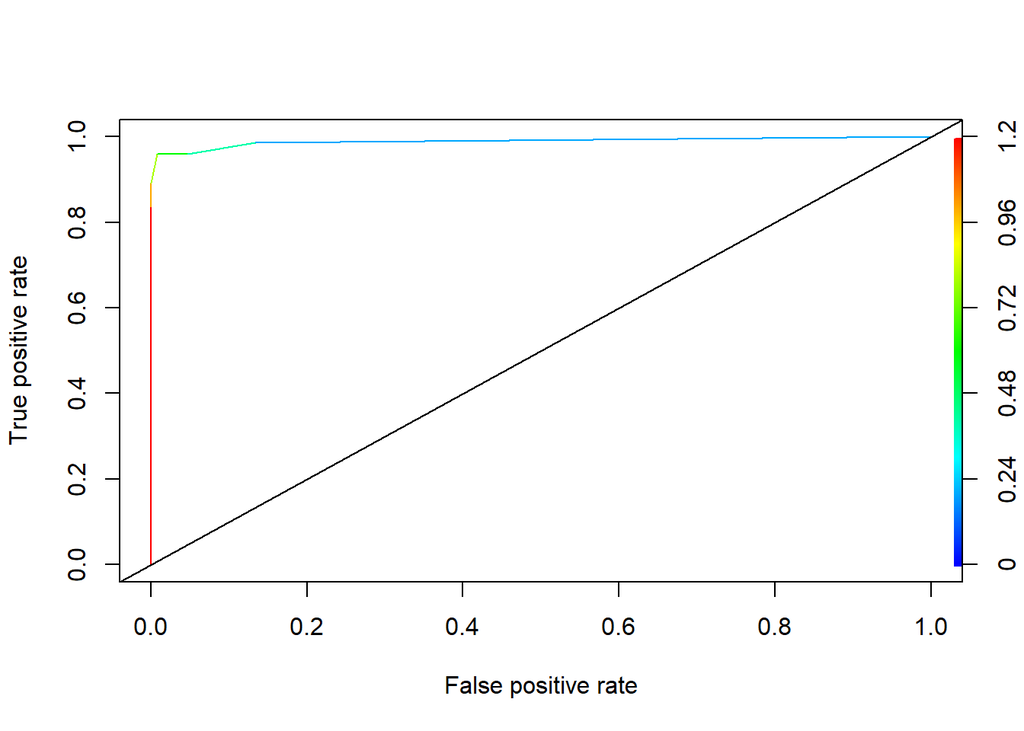

```r
pred <- prediction(cancer_eval$pred_prob, cancer_eval$target)

knn_perf <- performance(pred, "tpr", "fpr")
plot(knn_perf, colorize=TRUE)
abline(a=0, b=1)
```

```r
knn_perf_AUC <- performance(pred, "auc")

print(knn_perf_AUC@y.values)
```

```
## [[1]]
## [1] 0.9896255
```

The Area Under the Curve is a good indicator of the performance of the model. The AUC for the model is 0.9896255 which is in the excellent range. This means that the ratio of true positive rate to the false positive rate is high. The higher the AUC, the better the performance of the model is at distinguishing between the benign and malignant tumors. From the graph, we can see that the classifier will be able to detect more True positives and True negatives than False negatives and False positives.

#### LogLoss

```r
LogLoss(as.numeric(cancer_eval$pred_prob), as.numeric(cancer_test_car$diagnosis))
```

```
## [1] 8.714184
```

LogLoss: 8.714184

#### F1 Score

```r
F1_Score(as.numeric(cancer_eval$pred_class), as.numeric(cancer_test_car$diagnosis))
```

```
## [1] 0.984375
```

The F1 Score was calculated to be 0.984. The F1 score is used to balance Precision and Recall. Recall is important when there is a high cost associated with a false negative which is true in this case, because a patient could have a malignant tumor that is diagnosed as benign. In this case, a high F1 score means that there is a good ratio between Precision and Recall.

### Part 5. Modified Threshold Value

The first threshold that was used was 0.8. A higher threshold such as 0.8 in the context of our question means that no patients have the disease so the precision is said to increase and the recall decreases. However with the importance of not missing a malignant diagnosis, we want to increase the amount of true positives, which means that recall should be a high number because we want to find all the patients with the malignant tumor, however, this could also lead to low precision because we could diagnose benign tumors as malignant tumors.

#### Results of Modifications

By adjusting for a lower threshold, we reduce the amount of false negatives that could occur within the model’s classifier. The amount of false negatives seen in the confusion matrix with a threshold of 0.1 was lower than that of 0.8. Although the number of false positives increased, it is more important that the amount of false negatives decreased so that patients would be accurately diagnosed with a malignant tumor.

#### Modified Evaluation Metrics

```r
#First we need to do some predictions using the test data
cancer_evaln <-(predict(cancer_knn,newdata = cancer_test_car))#generates 1s and 0s
cancer_eval_probn <- predict(cancer_knn,newdata = cancer_test_car, type = "prob")#this gives us the predicted prob, we will need these later for the fairness evaluation
View(cancer_eval_probn)

#View(cancer_test_car$diagnosis)
#table(cancer_evaln, cancer_test_car$diagnosis)

adjust_thres(cancer_eval_probn$'1', 0.1, cancer_test_car$diagnosis)
```

```
## Confusion Matrix and Statistics
##
##           Actual
## Prediction   0   1
##          0 110   1
##          1  17  73
##
##                Accuracy : 0.9104
##                  95% CI : (0.8622, 0.9461)
##     No Information Rate : 0.6318
##     P-Value [Acc > NIR] : < 2.2e-16
##
##                   Kappa : 0.8158
##
##  Mcnemar's Test P-Value : 0.000407
##
##             Sensitivity : 0.9865
##             Specificity : 0.8661
##          Pos Pred Value : 0.8111
##          Neg Pred Value : 0.9910
##               Precision : 0.8111
##                  Recall : 0.9865
##                      F1 : 0.8902
##              Prevalence : 0.3682
##          Detection Rate : 0.3632
##    Detection Prevalence : 0.4478
##       Balanced Accuracy : 0.9263
##
##        'Positive' Class : 1
##
```

```r
# the algorithm predicted that one patient who has no cancer would be diagnosed with cancer // decrease the true positive rate // increased sensitivity
cancer_eval_probn$test <- cancer_test_car$diagnosis

(error = mean(cancer_evaln != cancer_test_car$diagnosis))
```

```
## [1] 0.0199005
```

```r
# the overall error rate is 0.0199
```

**Modified Evaluation Metrics from Confusion Matrix**

Accuracy: 0.9104

TPR: 0.9865

FPR: 0.1339

Kappa: 0.8158

F1: 0.8902

Prevalence: 0.3682

Balanced Accuracy: 0.9263

#### ROC/AUC Modified Plot

```r
cancer_evaln <- data.frame(pred_class=cancer_evaln, pred_prob=cancer_eval_probn$'1',target=as.numeric(cancer_test_car$diagnosis))
str(cancer_evaln)
```

```
## 'data.frame':    201 obs. of  3 variables:
##  $ pred_class: Factor w/ 2 levels "0","1": 2 2 2 2 2 2 1 2 2 2 ...
##  $ pred_prob : num  1 1 1 1 0.6 1 0 1 1 1 ...
##  $ target    : num  2 2 2 2 2 2 1 2 2 2 ...
```

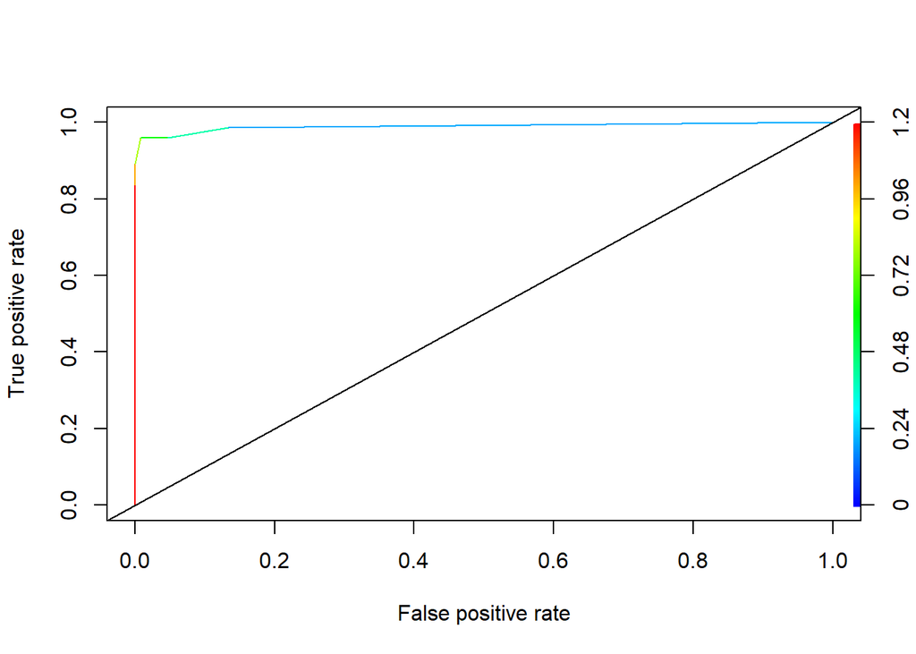

```r
predn <- prediction(cancer_evaln$pred_prob, cancer_evaln$target)

knn_perfn <- performance(predn, "tpr", "fpr")
plot(knn_perfn, colorize=TRUE)
abline(a=0, b=1)
```

```r
knn_perf_AUC <- performance(pred, "auc")

print(knn_perf_AUC@y.values)
```

```
## [[1]]
## [1] 0.9896255
```

The Area Under the Curve is a good indicator of the performance of the model. The AUC for the model is 0.9896255 which is in the excellent range. This means that the ratio of true positive rate to the false positive rate is high. The higher the AUC, the better the performance of the model is at distinguishing between the benign and malignant tumors. From the graph, we can see that the classifier will be able to detect more True positives and True negatives than False negatives and False positives.

#### Modified LogLoss

```r
LogLoss(as.numeric(cancer_evaln$pred_prob), as.numeric(cancer_test_car$diagnosis))
```

```
## [1] 8.714184
```

#### Modified F1 Score

```r
F1_Score(as.numeric(cancer_eval$pred_class), as.numeric(cancer_test_car$diagnosis))
```

```
## [1] 0.984375
```

The F1 score was used to balance Precision and Recall. Recall is important when there is a high cost associated with a false negative which is true in this case, because a patient could have a malignant tumor that is diagnosed as benign.

### Part 6. Results and Conclusion

Taking into account the evaluation metrics and the predictive capabilities of the model, he kNN model is a good model for classifying the diagnosis of a tumor; more specifically if it is benign or malignant. The evaluation outputs were as stated above. The most important evaluation metrics to solving our question were the false negative rate, balanced accuracy, and the F1 score. The false negative rate decreased with a lower threshold and this was important as it is necessary that the model does not misdiagnose patients with a malignant tumor and predict that they have a benign tumor. The balanced accuracy and F1 score are necessary because the data set is imbalanced and provides a more accurate evaluation of the model. The F1 score was high which meant that the precision to recall ratio. Recall is important when there is a high cost associated with a false negative which is true in this case, because a patient could have a malignant tumor that is diagnosed as benign. However, because the F1 score is high, we can have confidence that the model is better at predicting the false negatives and overall the true rates.

Some recommendations for improvement include gathering more data which might balance out the dataset, but could lead to some bias. Other than that, the model works well based on the F1 score, balanced accuracy, and the false negative rate.